# Barometre numerique

AT-TP-SC

19/06/2020

[figure not shown]

## Groupe

CASELLA Sendy PLOBNER Thomas THOMANN Antoine

```r
knitr::opts_chunk$set(echo = TRUE)
library(readr)
library(ggplot2)
library(dplyr)
library(hrbrthemes)
library(tidyverse)
library(viridisLite)
library(viridis)
library(forcats)
library(tidyr)
library(car)
```

## Initialisation du programme

Avec cette première partie de code, nous faisons appel aux différents packages que nous allons utiliser pour traiter le set de données que nous avons choisi. Il s’agit du Baromètre du Numérique, publié tous les ans par l’Arcep, le Conseil général de l’économie (CGE) et l’Agence du Numérique.

Le fichier source est trouvable à l’addresse suivante : https://www.data.gouv.fr/fr/datasets/barometre-du-numerique/.

```r
#Chargement du fichier CSV
barom_num <- read_delim("barometredunumerique_2007_2019_fus_Copie.csv", ";", escape_double = FALSE,trim_ws = TRUE)
#Recodage en facteurs
barom_num$SD.Sexe <-as.factor(barom_num$SEXE)
barom_num$SD.Categorie.age <-as.factor(barom_num$AGE6FUZ)
barom_num$SD.CSP <-as.factor(barom_num$PCS8EGO)
barom_num$SD.Niveau.diplome <-as.factor(barom_num$DIPL5)
barom_num$SD.Taille.agglomeration <-as.factor(barom_num$AGGLO5)
barom_num$UG.Competence <-as.factor(barom_num$ABILITY)
barom_num$UG.Frein.internet <-as.factor(barom_num$FREINWEB)
barom_num$UG.Smartphone <-as.factor(barom_num$SMARTPHO)
barom_num$UG.Connexion.internet.fixe <-as.factor(barom_num$INTERNET)
barom_num$UG.Connexion.internet.mobile <-as.factor(barom_num$ALLMOBI)
barom_num$UG.Frequence.connexion.internet <-as.factor(barom_num$FREQTOT)
barom_num$UG.Frequence.ordinateur <-as.factor(barom_num$FREQORDI)
barom_num$UG.Frequence.smartphone <-as.factor(barom_num$FREQMOB)
barom_num$UG.Equipement.prefere.internet <-as.factor(barom_num$PREFWEB)
barom_num$UG.Utilite.ordinateur <-as.factor(barom_num$UTILORDI)
barom_num$UG.Utilité.smartphone <-as.factor(barom_num$UTILSMAR)
barom_num$RRSS.divertissement <-as.factor(barom_num$FACEFUN)
barom_num$RRSS.lien.proches <-as.factor(barom_num$FACELIEN)
barom_num$RRSS.info.actu <-as.factor(barom_num$FACENEWS)
barom_num$RRSS.Media.suivi.actu <-as.factor(barom_num$ACTUMED1)
barom_num$RRSS.Media.comprehension.actu <-as.factor(barom_num$ACTUMED2)
barom_num$RRSS.1er.media.confiance <-as.factor(barom_num$MEDIA1)
barom_num$RRSS.2nd.media.confiance <-as.factor(barom_num$MEDIA2)

#Création du fichier de référence

fs <- data.frame(barom_num$annee, barom_num$SD.Sexe, barom_num$SD.Categorie.age, barom_num$SD.CSP, barom_num$SD.Niveau.diplome, barom_num$SD.Taille.agglomeration, barom_num$UG.Competence,  barom_num$UG.Frein.internet, barom_num$UG.Smartphone,barom_num$UG.Connexion.internet.fixe, barom_num$UG.Connexion.internet.mobile, barom_num$UG.Frequence.connexion.internet, barom_num$UG.Frequence.ordinateur, barom_num$UG.Frequence.smartphone, barom_num$UG.Equipement.prefere.internet, barom_num$UG.Utilite.ordinateur, barom_num$UG.Utilité.smartphone, barom_num$RRSS.divertissement, barom_num$RRSS.lien.proches, barom_num$RRSS.info.actu, barom_num$RRSS.Media.suivi.actu, barom_num$RRSS.Media.comprehension.actu, barom_num$RRSS.1er.media.confiance, barom_num$RRSS.2nd.media.confiance)

fs1 <- fs
```

## Traitement du fichier source

La première étape consiste à transformer en facteurs les différentes variables que nous allons utiliser pour notre analyse. Il s’agit du format approprié car celles-ci constituent des variables quantitatives avec une échelle définie.

Nous avons décidé de nous concentrer autour de trois catégories majeures : * Critères socio-démographiques : labélisés “SD.[…]” * Critères d’usage : labélisés “UG.[…]” * Critères de rapport aux réseaux sociaux comme média : labélisés “RRSS.[…]”

Afin de faciliter les traitements et la lisibilité du fichier source, nous avons créé un dataframe pour stocker les différentes variables servant à notre analyse.

```r
# CAMEMBERT 1 : REPARTITION AGE ECHANTILLON

data_age <- barom_num%>%group_by(SD.Categorie.age)%>%
  dplyr::summarize(count=n(),
                  AgePourcentage=n()/nrow(barom_num))
```

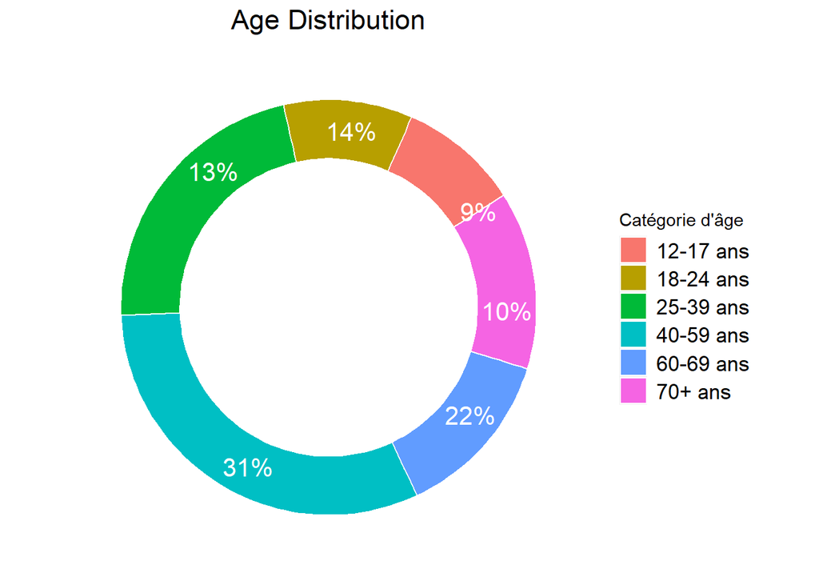

```r
AgePie <- ggplot(data=data_age, aes(x=3, y=AgePourcentage, fill=SD.Categorie.age))+ geom_col(color="white") +
coord_polar("y", start=1)+
geom_text(aes(label=paste0(round(AgePourcentage*100),"%")),
                position=position_stack(vjust=0,5), size=I(5.5),color="white")+ theme(panel.background=element_blank(),
      axis.line=element_blank(),
      axis.title=element_blank(),
      axis.ticks=element_blank(),
      axis.text=element_blank(),
      legend.text=element_text(size=I(13)),
      plot.title=element_text(hjust=0.5,size= I(17)))+ggtitle("Age Distribution")+
      xlim(0.3,3.5)
AgePie + scale_fill_discrete(name = "Catégorie d'âge", labels = c("12-17 ans", "18-24 ans", "25-39 ans", "40-59 ans", "60-69 ans", "70+ ans"))
```

## Graphique n°1 : répartition des âges dans l’échantillon

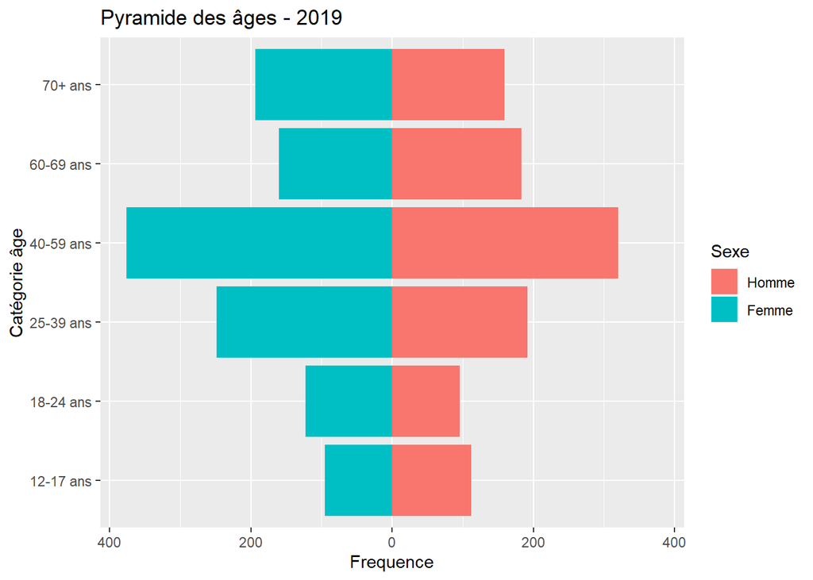

```r
#Préparation des données

pyage <-data.frame(fs$barom_num.annee, fs$barom_num.SD.Sexe, fs$barom_num.SD.Categorie.age)
pyage <- subset(pyage, fs.barom_num.annee==2019)
pyage <- setNames(data.frame(table(pyage$fs.barom_num.SD.Categorie.age, pyage$fs.barom_num.SD.Sexe)), c("Categorie.age", "Sexe", "Frequence"))

  #Graphique
pyr <- ggplot(pyage, aes(x=Categorie.age, y=ifelse(test= Sexe ==1, yes = Frequence, no = -Frequence), fill=Sexe))+geom_col()+coord_flip()+scale_y_continuous(labels = abs, limits = max(pyage$Frequence) * c(-1,1)) +
    labs(title="Pyramide des âges - 2019", x="Catégorie âge", y = "Frequence")
pyr+scale_fill_discrete(name = "Sexe", labels = c("Homme", "Femme")) + scale_x_discrete(breaks=c("1","2","3", "4", "5", "6"),
        labels=c("12-17 ans", "18-24 ans", "25-39 ans", "40-59 ans", "60-69 ans", "70+ ans"))
```

## Graphique n°2 : Pyramide des ages pour 2019

Sur ce graphique, nous pouvons observer que la catégorie la plus représentée sont les 40-59 ans, suivis des 25-39 ans. Il semble y avoir légèrement plus de femmes que d’hommes. La catégorie la moins représentée sont les mineurs.

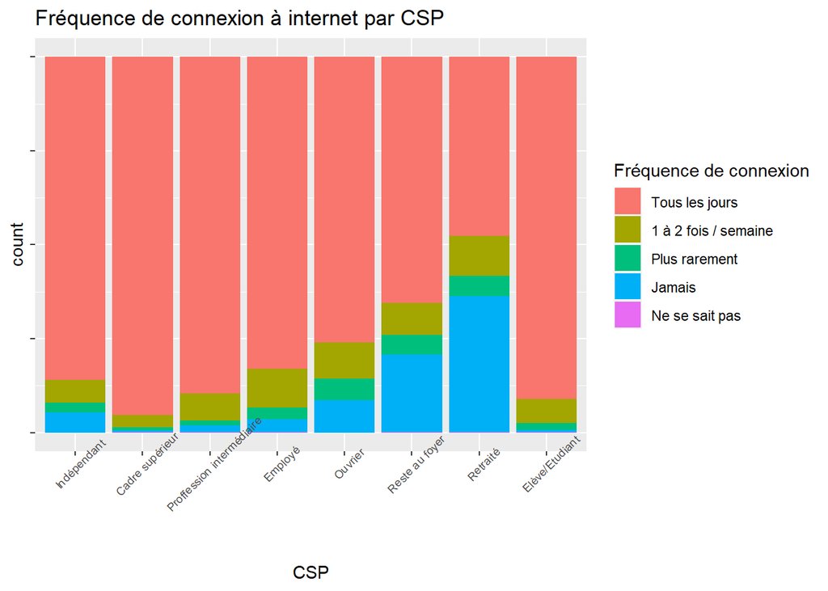

```r
data_graph1 <- filter(fs, barom_num$annee %in% c(2015, 2016, 2017,2018,2019)) # création table de 2015 à 2019 (afin de supprimer les années où le sondage n'a pas été fait)

g1 <- ggplot(data_graph1) +
  aes(x = barom_num.SD.CSP, fill = barom_num.UG.Frequence.connexion.internet) +
  geom_bar(position = "fill")

g1+ scale_fill_discrete(name = "Fréquence de connexion", labels = c("Tous les jours", "1 à 2 fois / semaine", "Plus rarement", "Jamais", "Ne se sait pas")) + scale_x_discrete(breaks=c("1","2","3", "4", "5", "6", "7", "8"),
        labels=c("Indépendant", "Cadre supérieur", "Proffession intermédiaire", "Employé", "Ouvrier", "Reste au foyer", "Retraité", "Elève/Etudiant")) + theme(axis.text.x = element_text(size=7, angle=45), axis.text.y = element_blank())+
    labs(title="Fréquence de connexion à internet par CSP", x="CSP")
```

## Graphique n°3 : Fréquences de connexion par CSP

De manière générale, quelle que soit la CSP, l’immense majorité des répondants se connectent au moins une fois par jour. Cette affirmation peut être nuancée pour la catégorie retraités, qui sont la population avec la majeure propension à ne jamais se connecter.

```r
# CREATION D'UNE TABLE PAR CATEGORIE D'AGE AVEC COMME FILTRE LES TROIS DERNIERES ANNEES, LE SONDAGE SUR CETTE QUESTION AYANT COMMENCE EN 2017

data_2017a2019_cat1 <- filter(fs, barom_num$annee %in% c(2017,2018,2019) & barom_num$SD.Categorie.age==1) # Table catégorie 1
data_2017a2019_cat2 <- filter(fs, barom_num$annee %in% c(2017,2018,2019) & barom_num$SD.Categorie.age==2) # Table catégorie 2
data_2017a2019_cat3 <- filter(fs, barom_num$annee %in% c(2017,2018,2019) & barom_num$SD.Categorie.age==3) # Table catégorie 3
data_2017a2019_cat4 <- filter(fs, barom_num$annee %in% c(2017,2018,2019) & barom_num$SD.Categorie.age==4) # Table catégorie 4
data_2017a2019_cat5 <- filter(fs, barom_num$annee %in% c(2017,2018,2019) & barom_num$SD.Categorie.age==5) # Table catégorie 5
data_2017a2019_cat6 <- filter(fs, barom_num$annee %in% c(2017,2018,2019) & barom_num$SD.Categorie.age==6) # Table catégorie 6


# DIAGRAMME CATEGORIE 1

data_prefwebcat1 <- data_2017a2019_cat1%>%group_by(barom_num.UG.Equipement.prefere.internet)%>%
  dplyr::summarize(count=n(),
                  PrefPourcentage=n()/nrow(data_2017a2019_cat1))
```

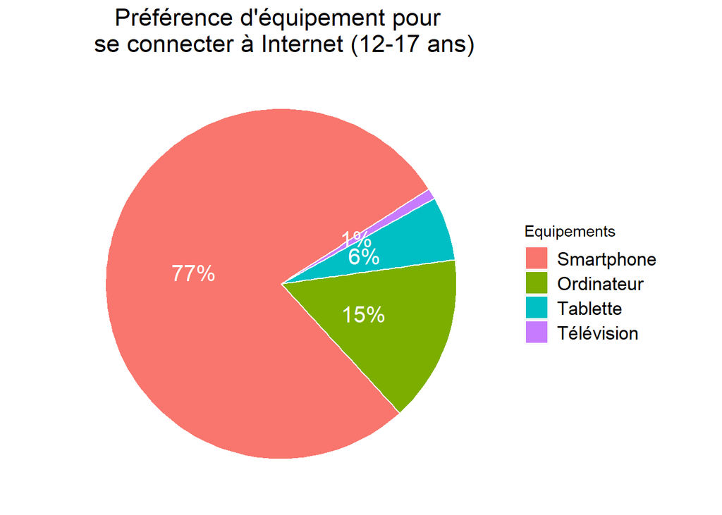

```r
data_prefwebcat1 <- subset(data_prefwebcat1, barom_num.UG.Equipement.prefere.internet !=99)

Cat1Pie <- ggplot(data=data_prefwebcat1, aes(x=3, y=PrefPourcentage, fill=barom_num.UG.Equipement.prefere.internet))+ geom_col(color="white") +
coord_polar("y", start=1)+
geom_text(aes(label=paste0(round(PrefPourcentage*100),"%")),
                position=position_stack(vjust=0.5), size=I(5.5),color="white")+ theme(panel.background=element_blank(),
      axis.line=element_blank(),
      axis.title=element_blank(),
      axis.ticks=element_blank(),
      axis.text=element_blank(),
      legend.text=element_text(size=I(13)),
      plot.title=element_text(hjust=0.5,size= I(17)))+ggtitle("Préférence d'équipement pour \n se connecter à Internet (12-17 ans)")
Cat1Pie + scale_fill_discrete(name = "Equipements", labels = c("Smartphone", "Ordinateur", "Tablette", "Télévision", "Ne se connecte jamais", "_", "Ne sait pas"))
```

```r
# DIAGRAMME CATEGORIE 2

data_prefwebcat2 <- data_2017a2019_cat2%>%group_by(barom_num.UG.Equipement.prefere.internet)%>%
  dplyr::summarize(count=n(),
                  PrefPourcentage2=n()/nrow(data_2017a2019_cat2))
```

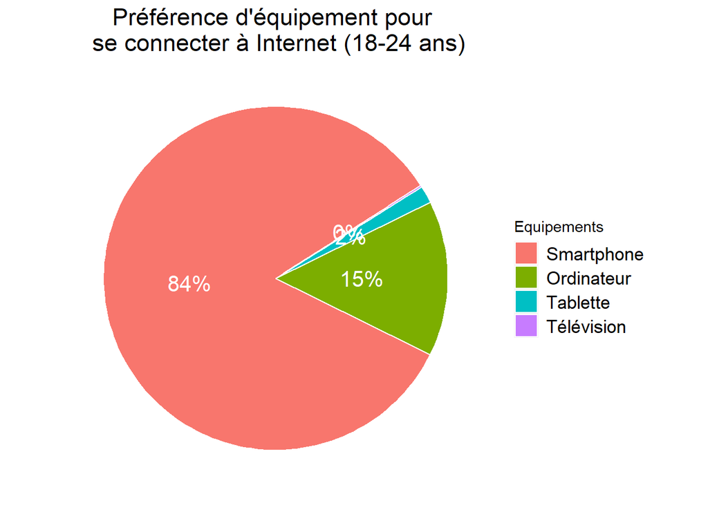

```r
data_prefwebcat2 <- subset(data_prefwebcat2, barom_num.UG.Equipement.prefere.internet !=99)

Cat2Pie <- ggplot(data=data_prefwebcat2, aes(x=3, y=PrefPourcentage2, fill=barom_num.UG.Equipement.prefere.internet))+ geom_col(color="white") +
coord_polar("y", start=1)+
geom_text(aes(label=paste0(round(PrefPourcentage2*100),"%")),
                position=position_stack(vjust=0.5), size=I(5.5),color="white")+ theme(panel.background=element_blank(),
      axis.line=element_blank(),
      axis.title=element_blank(),
      axis.ticks=element_blank(),
      axis.text=element_blank(),
      legend.text=element_text(size=I(13)),
      plot.title=element_text(hjust=0.5,size= I(17)))+ggtitle("Préférence d'équipement pour \n se connecter à Internet (18-24 ans)")
Cat2Pie + scale_fill_discrete(name = "Equipements", labels = c("Smartphone", "Ordinateur", "Tablette", "Télévision", "Ne se connecte jamais", "_", "Ne sait pas"))
```

```r
# DIAGRAMME CATEGORIE 3

data_prefwebcat3 <- data_2017a2019_cat3%>%group_by(barom_num.UG.Equipement.prefere.internet)%>%
  dplyr::summarize(count=n(),
                  PrefPourcentage3=n()/nrow(data_2017a2019_cat3))
```

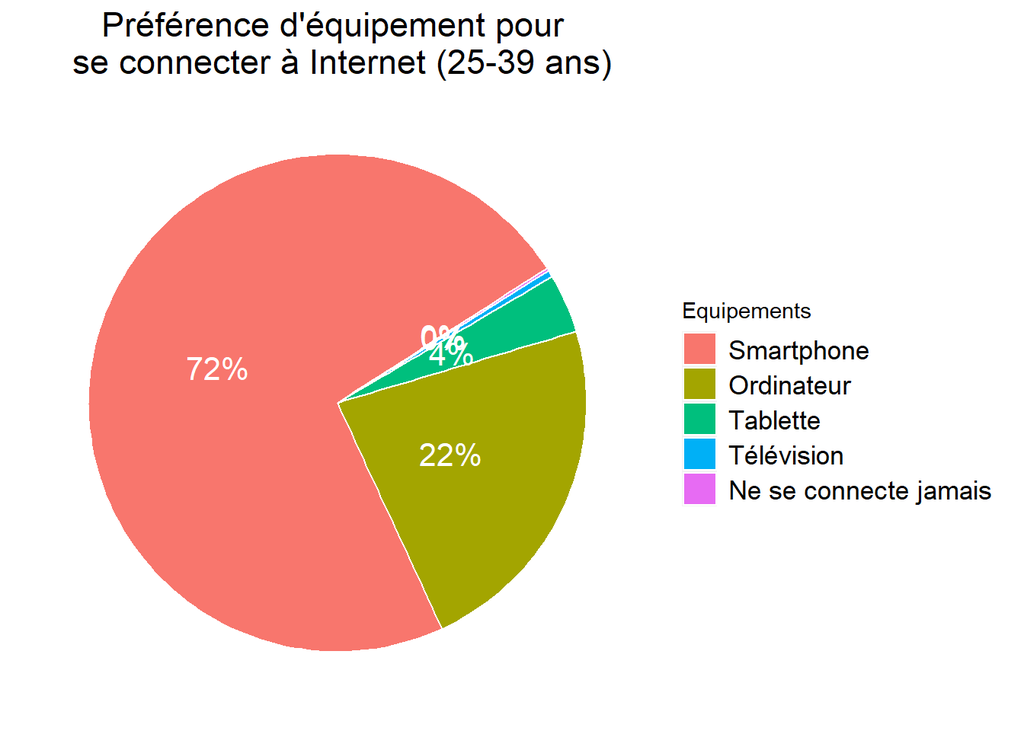

```r
data_prefwebcat3 <- subset(data_prefwebcat3, barom_num.UG.Equipement.prefere.internet !=99)

Cat3Pie <- ggplot(data=data_prefwebcat3, aes(x=3, y=PrefPourcentage3, fill=barom_num.UG.Equipement.prefere.internet))+ geom_col(color="white") +
coord_polar("y", start=1)+
geom_text(aes(label=paste0(round(PrefPourcentage3*100),"%")),
                position=position_stack(vjust=0.5), size=I(5.5),color="white")+ theme(panel.background=element_blank(),
      axis.line=element_blank(),
      axis.title=element_blank(),
      axis.ticks=element_blank(),
      axis.text=element_blank(),
      legend.text=element_text(size=I(13)),
      plot.title=element_text(hjust=0.5,size= I(17)))+ggtitle("Préférence d'équipement pour \n se connecter à Internet (25-39 ans)")
Cat3Pie + scale_fill_discrete(name = "Equipements", labels = c("Smartphone", "Ordinateur", "Tablette", "Télévision", "Ne se connecte jamais", "_", "Ne sait pas"))
```

```r
# DIAGRAMME CATEGORIE 4

data_prefwebcat4 <- data_2017a2019_cat4%>%group_by(barom_num.UG.Equipement.prefere.internet)%>%
  dplyr::summarize(count=n(),
                  PrefPourcentage4=n()/nrow(data_2017a2019_cat4))
```

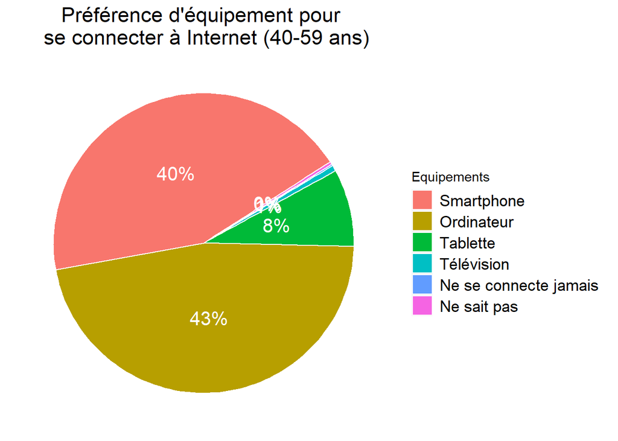

```r
data_prefwebcat4 <- subset(data_prefwebcat4, barom_num.UG.Equipement.prefere.internet !=99)

Cat4Pie <- ggplot(data=data_prefwebcat4, aes(x=3, y=PrefPourcentage4, fill=barom_num.UG.Equipement.prefere.internet))+ geom_col(color="white") +
coord_polar("y", start=1)+
geom_text(aes(label=paste0(round(PrefPourcentage4*100),"%")),
                position=position_stack(vjust=0.5), size=I(5.5),color="white")+ theme(panel.background=element_blank(),
      axis.line=element_blank(),
      axis.title=element_blank(),
      axis.ticks=element_blank(),
      axis.text=element_blank(),
      legend.text=element_text(size=I(13)),
      plot.title=element_text(hjust=0.5,size= I(17)))+ggtitle("Préférence d'équipement pour \n se connecter à Internet (40-59 ans)")
Cat4Pie + scale_fill_discrete(name = "Equipements", labels = c("Smartphone", "Ordinateur", "Tablette", "Télévision", "Ne se connecte jamais", "Ne sait pas"))
```

```r
# DIAGRAMME CATEGORIE 5

data_prefwebcat5 <- data_2017a2019_cat5%>%group_by(barom_num.UG.Equipement.prefere.internet)%>%
  dplyr::summarize(count=n(),
                  PrefPourcentage5=n()/nrow(data_2017a2019_cat5))
```

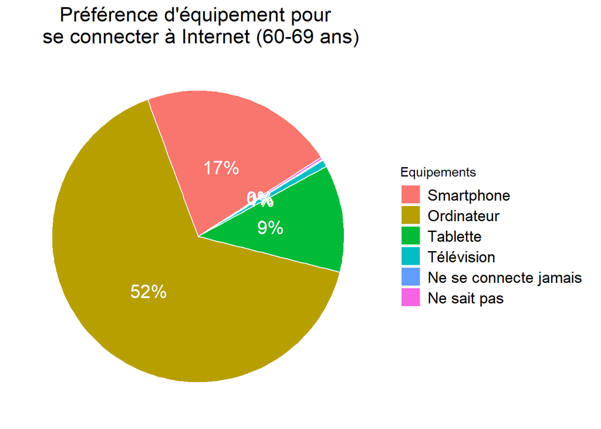

```r
data_prefwebcat5 <- subset(data_prefwebcat5, barom_num.UG.Equipement.prefere.internet !=99)

Cat5Pie <- ggplot(data=data_prefwebcat5, aes(x=3, y=PrefPourcentage5, fill=barom_num.UG.Equipement.prefere.internet))+ geom_col(color="white") +
coord_polar("y", start=1)+
geom_text(aes(label=paste0(round(PrefPourcentage5*100),"%")),
                position=position_stack(vjust=0.5), size=I(5.5),color="white")+ theme(panel.background=element_blank(),
      axis.line=element_blank(),
      axis.title=element_blank(),
      axis.ticks=element_blank(),
      axis.text=element_blank(),
      legend.text=element_text(size=I(13)),
      plot.title=element_text(hjust=0.5,size= I(17)))+ggtitle("Préférence d'équipement pour \n se connecter à Internet (60-69 ans)")
Cat5Pie + scale_fill_discrete(name = "Equipements", labels = c("Smartphone", "Ordinateur", "Tablette", "Télévision", "Ne se connecte jamais", "Ne sait pas"))
```

```r
# DIAGRAMME CATEGORIE 6

data_prefwebcat6 <- data_2017a2019_cat6%>%group_by(barom_num.UG.Equipement.prefere.internet)%>%
  dplyr::summarize(count=n(),
                  PrefPourcentage6=n()/nrow(data_2017a2019_cat6))
```

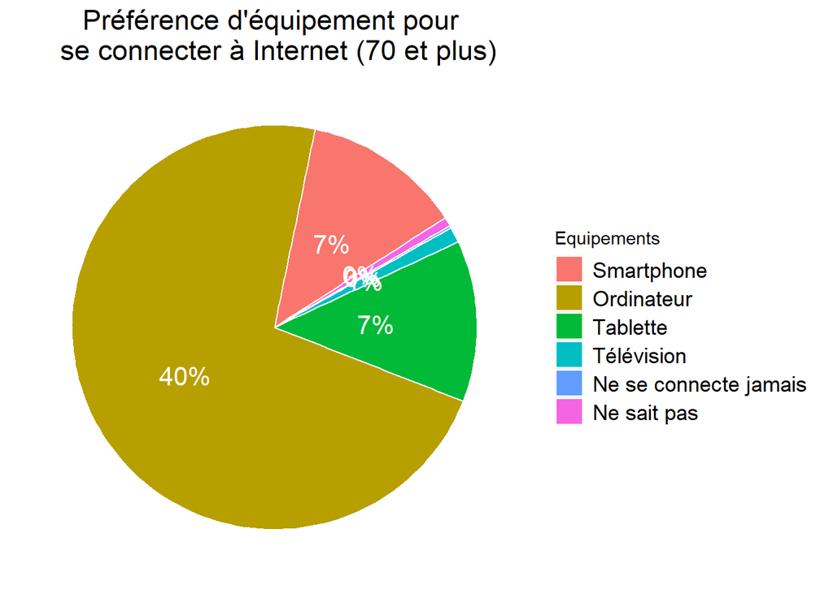

```r
data_prefwebcat6 <- subset(data_prefwebcat6, barom_num.UG.Equipement.prefere.internet !=99)

Cat6Pie <- ggplot(data=data_prefwebcat6, aes(x=3, y=PrefPourcentage6, fill=barom_num.UG.Equipement.prefere.internet))+ geom_col(color="white") +
coord_polar("y", start=1)+
geom_text(aes(label=paste0(round(PrefPourcentage6*100),"%")),
                position=position_stack(vjust=0.5), size=I(5.5),color="white")+ theme(panel.background=element_blank(),
      axis.line=element_blank(),
      axis.title=element_blank(),
      axis.ticks=element_blank(),
      axis.text=element_blank(),
      legend.text=element_text(size=I(13)),
      plot.title=element_text(hjust=0.5,size= I(17)))+ggtitle("Préférence d'équipement pour \n se connecter à Internet (70 et plus)")
Cat6Pie + scale_fill_discrete(name = "Equipements", labels = c("Smartphone", "Ordinateur", "Tablette", "Télévision", "Ne se connecte jamais", "Ne sait pas"))
```